# Assignment 2: Spatial Analysis and Visualization

Healthcare Access and Equity in Pennsylvania

Author

Fan Yang

Published

September 29, 2025

## Assignment Overview

**Learning Objectives:** - Apply spatial operations to answer policy-relevant research questions - Integrate census demographic data with spatial analysis - Create publication-quality visualizations and maps - Work with spatial data from multiple sources - Communicate findings effectively for policy audiences

## Part 1: Healthcare Access for Vulnerable Populations

### Research Question

**Which Pennsylvania counties have the highest proportion of vulnerable populations (elderly + low-income) living far from hospitals?**

Your analysis should identify counties that should be priorities for healthcare investment and policy intervention.

### Required Analysis Steps

Complete the following analysis, documenting each step with code and brief explanations:

#### Step 1: Data Collection (5 points)

Load the required spatial data: - Pennsylvania county boundaries - Pennsylvania hospitals (from lecture data) - Pennsylvania census tracts

**Your Task:**

```r
# Load required packages
library(sf)
library(tidyverse)
library(tidycensus)
library(tigris)
library(ggplot2)
library(knitr)
library(kableExtra)
library(units)
library(patchwork)
library(ggspatial)
```

```r
# Load spatial data
library(here)
options(tigris_use_cache = TRUE)
options(tigris_progress = FALSE)
pa_counties <- st_read(here("assignments", "assignment_2", "data", "Pennsylvania_County_Boundaries.shp"))
hospitals   <- st_read(here("assignments", "assignment_2", "data", "hospitals.geojson"))
pa_tracts <- tracts("PA", year = 2022, cb = TRUE)

# Create summary table of dataset information
dataset_summary <- data.frame(
  Dataset = c("Hospitals", "Census Tracts", "Counties", "Hospitals", "Census Tracts"),
  Metric = c("Count", "Count", "Count", "CRS", "CRS"),
  Value = c(
    nrow(hospitals),
    nrow(pa_tracts),
    nrow(pa_counties),
    st_crs(pa_counties)$input,
    st_crs(pa_tracts)$input
  )
)

kable(dataset_summary,
      col.names = c("Dataset", "Metric", "Value"),
      caption = "Spatial Dataset Summary",
      align = c("l", "l", "l"))
```

Spatial Dataset Summary

| Dataset | Metric | Value |
| --- | --- | --- |
| Hospitals | Count | 223 |
| Census Tracts | Count | 3445 |
| Counties | Count | 67 |
| Hospitals | CRS | WGS 84 / Pseudo-Mercator |
| Census Tracts | CRS | NAD83 |

**Questions to answer:**

- How many hospitals are in your dataset? **223**
- How many census tracts? **3,445**
- What coordinate reference system is each dataset in?
  - Counties: WGS 84 / Pseudo-Mercator
  - Hospitals: WGS 84
  - Census tracts: NAD83

#### Step 2: Get Demographic Data

Use `tidycensus` to download tract-level demographic data for Pennsylvania.

**Required variables:**

- Total population
- Median household income
- Population 65 years and over (you may need to sum multiple age categories)

**Your Task:**

```r
# Get demographic data from ACS

# Get demographic data for Pennsylvania tracts
pa_demographics <- get_acs(
  geography = "tract",
  state = "PA",
  variables = c(
    total_pop = "B01003_001",           # Total population
    median_income = "B19013_001",       # Median household income
    pop_65_74 = "B01001_020",          # Population 65-74 years
    pop_75_84 = "B01001_021",          # Population 75-84 years
    pop_85_plus = "B01001_022"         # Population 85 years and over
  ),
  year = 2022,
  geometry = TRUE
)

# Pivot the data to wide format
pa_demographics_wide <- pa_demographics %>%
  select(GEOID, NAME, variable, estimate) %>%
  pivot_wider(names_from = variable, values_from = estimate) %>%
  # Calculate total elderly population (65+)
  mutate(
    pop_65_plus = pop_65_74 + pop_75_84 + pop_85_plus,
    elderly_pct = (pop_65_plus / total_pop) * 100
  )

# Join to tract boundaries (already have geometry from get_acs)
tracts_with_demographics <- pa_demographics_wide

# Check for missing data and create summary table
demographics_summary <- data.frame(
  Metric = c("Missing Income Data", "Median Income (All Tracts)"),
  Value = c(
    paste(sum(is.na(tracts_with_demographics$median_income)), "tracts"),
    paste("$", format(median(tracts_with_demographics$median_income, na.rm = TRUE), big.mark = ","))
  )
)

kable(demographics_summary,
      col.names = c("Metric", "Value"),
      caption = "Demographics Data Quality Summary",
      align = c("l", "l"))
```

Demographics Data Quality Summary

| Metric | Value |
| --- | --- |
| Missing Income Data | 63 tracts |
| Median Income (All Tracts) | $ 70,188 |

**Questions to answer:**

- What year of ACS data are you using? **2022**
- How many tracts have missing income data? **63 tracts**
- What is the median income across all PA census tracts? **$70,188**

#### Step 3: Define Vulnerable Populations

Identify census tracts with vulnerable populations based on TWO criteria: 1. Low median household income (choose an appropriate threshold) 2. Significant elderly population (choose an appropriate threshold)

**Your Task:**

```r
# Filter for vulnerable tracts based on your criteria
# Define thresholds for vulnerability
income_threshold <- 60000  # Median household income below $60,000 (85% of PA median)
elderly_threshold <- 15    # Elderly population above 15% (typical baseline threshold)

# Create vulnerable population indicator
vulnerable_tracts <- tracts_with_demographics %>%
  filter(!is.na(median_income)) %>%  # Remove tracts with missing income data
  mutate(
    low_income = median_income < income_threshold,
    high_elderly = elderly_pct > elderly_threshold,
    vulnerable = low_income | high_elderly  # OR logic: either low income OR high elderly
  )

# Create summary table of vulnerability criteria and results
vulnerability_summary <- data.frame(
  Metric = c(
    "Income Threshold",
    "PA Median Income",
    "Elderly Threshold",
    "Low Income Tracts",
    "High Elderly Tracts",
    "Vulnerable Tracts (Either)",
    "Percentage Vulnerable"
  ),
  Value = c(
    paste("$", format(income_threshold, big.mark = ",")),
    paste("$", format(median(tracts_with_demographics$median_income, na.rm = TRUE), big.mark = ",")),
    paste(elderly_threshold, "%"),
    sum(vulnerable_tracts$low_income),
    sum(vulnerable_tracts$high_elderly),
    sum(vulnerable_tracts$vulnerable),
    paste(round(sum(vulnerable_tracts$vulnerable) / nrow(vulnerable_tracts) * 100, 1), "%")
  )
)

kable(vulnerability_summary,
      col.names = c("Metric", "Value"),
      caption = "Vulnerability Criteria and Results Summary",
      align = c("l", "l"))
```

Vulnerability Criteria and Results Summary

| Metric | Value |
| --- | --- |
| Income Threshold | $ 60,000 |
| PA Median Income | $ 70,188 |
| Elderly Threshold | 15 % |
| Low Income Tracts | 1112 |
| High Elderly Tracts | 6 |
| Vulnerable Tracts (Either) | 1116 |
| Percentage Vulnerable | 33 % |

**Questions to answer:**

- What income threshold did you choose and why?  
  **$60,000** (85% of PA median), moderately low-income households
- What elderly population threshold did you choose and why?  
  **15%** (above typical baseline). Used OR logic (low income OR high elderly) instead of AND, as both criteria together were too restrictive.
- How many tracts meet your vulnerability criteria? **1,116 tracts**
- What percentage of PA census tracts are considered vulnerable by your definition? **33%**

#### Step 4: Calculate Distance to Hospitals

For each vulnerable tract, calculate the distance to the nearest hospital.

**Your Task:**

```r
# Transform to appropriate projected CRS
# Use Pennsylvania State Plane South (EPSG:2272) for accurate distance calculations
pa_crs <- 2272  # Pennsylvania State Plane South

# Transform all datasets to the same CRS
vulnerable_tracts_proj <- st_transform(vulnerable_tracts, pa_crs)
hospitals_proj <- st_transform(hospitals, pa_crs)

# Calculate distance from each tract centroid to nearest hospital
# Get centroids of vulnerable tracts
tract_centroids <- st_centroid(vulnerable_tracts_proj)

# Calculate distance matrix between tract centroids and hospitals
distances <- st_distance(tract_centroids, hospitals_proj)

# Find minimum distance to nearest hospital for each tract
min_distances <- apply(distances, 1, min)

# Convert from meters to miles (1 meter = 0.000621371 miles)
min_distances_miles <- as.numeric(min_distances) * 0.000621371

# Add distance information to vulnerable tracts
vulnerable_tracts_with_distance <- vulnerable_tracts_proj %>%
  mutate(
    distance_to_hospital_miles = min_distances_miles
  )

# Create summary table of distance statistics
distance_summary <- data.frame(
  Metric = c(
    "Average Distance",
    "Maximum Distance",
    "Tracts >15 miles from Hospital"
  ),
  Value = c(
    paste(round(mean(min_distances_miles), 2), "miles"),
    paste(round(max(min_distances_miles), 2), "miles"),
    sum(min_distances_miles > 15)
  )
)

kable(distance_summary,
      col.names = c("Metric", "Value"),
      caption = "Distance to Nearest Hospital Summary",
      align = c("l", "l"))
```

Distance to Nearest Hospital Summary

[output not shown]

**Requirements:**

- Use an appropriate projected coordinate system for Pennsylvania
- Calculate distances in miles
- Explain why you chose your projection

#### Step 5: Identify Underserved Areas

Define “underserved” as vulnerable tracts that are more than 15 miles from the nearest hospital.

**Your Task:**

```r
# Create underserved variable
# Define "underserved" as vulnerable tracts more than 15 miles from nearest hospital
underserved_threshold <- 15  # miles

# Add underserved indicator
vulnerable_tracts_final <- vulnerable_tracts_with_distance %>%
  mutate(
    underserved = vulnerable & (distance_to_hospital_miles > underserved_threshold)
  )

# Create summary table of underserved analysis
total_vulnerable <- sum(vulnerable_tracts_final$vulnerable)
total_underserved <- sum(vulnerable_tracts_final$underserved)

underserved_summary <- data.frame(
  Metric = c(
    "Underserved Threshold",
    "Number of Underserved Tracts",
    "Percentage of Vulnerable Tracts Underserved",
    "Assessment"
  ),
  Value = c(
    paste(underserved_threshold, "miles"),
    total_underserved,
    paste(round(total_underserved / total_vulnerable * 100, 1), "%"),
    ifelse(total_underserved > total_vulnerable * 0.3, "Concerning", "Somewhat Expected")
  )
)

kable(underserved_summary,
      col.names = c("Metric", "Value"),
      caption = "Underserved Population Analysis Summary",
      align = c("l", "l"))
```

Underserved Population Analysis Summary

| Metric | Value |
| --- | --- |
| Underserved Threshold | 15 miles |
| Number of Underserved Tracts | 251 |
| Percentage of Vulnerable Tracts Underserved | 22.5 % |
| Assessment | Somewhat Expected |

**Questions to answer:**

- How many tracts are underserved? **251 tracts**
- What percentage of vulnerable tracts are underserved? **22.5%**
- Does this surprise you? Why or why not?  
  Somewhat concerning. 22.5% of vulnerable tracts (251 tracts) are underserved (>15 miles from hospital). Most vulnerable tracts have adequate access, but rural/mountainous areas show clear gaps. May need mobile clinics or telehealth for these areas.

#### Step 6: Aggregate to County Level

Use spatial joins and aggregation to calculate county-level statistics about vulnerable populations and hospital access.

**Your Task:**

```r
# Spatial join tracts to counties
# Transform counties to same CRS
pa_counties_proj <- st_transform(pa_counties, pa_crs)

# Spatial join tracts to counties
tracts_with_counties <- st_join(vulnerable_tracts_final, pa_counties_proj, join = st_within)

# Aggregate statistics by county
county_stats <- tracts_with_counties %>%
  st_drop_geometry() %>%  # Remove geometry for aggregation
  group_by(COUNTY_NAM) %>%
  summarise(
    total_tracts = n(),
    vulnerable_tracts = sum(vulnerable, na.rm = TRUE),
    underserved_tracts = sum(underserved, na.rm = TRUE),
    pct_vulnerable_underserved = ifelse(vulnerable_tracts > 0,
                                       round(underserved_tracts / vulnerable_tracts * 100, 1), 0),
    avg_distance_vulnerable = ifelse(vulnerable_tracts > 0,
                                    round(mean(distance_to_hospital_miles[vulnerable], na.rm = TRUE), 2), 0),
    total_vulnerable_pop = sum(total_pop[vulnerable], na.rm = TRUE),
    .groups = 'drop'
  ) %>%
  filter(vulnerable_tracts > 0) %>%  # Only include counties with vulnerable tracts
  arrange(desc(pct_vulnerable_underserved))

# Create summary tables for top counties
top_5_underserved <- head(county_stats, 5) %>%
  select(County = COUNTY_NAM, `% Underserved` = pct_vulnerable_underserved) %>%
  mutate(Rank = row_number())

top_5_population <- county_stats %>%
  arrange(desc(total_vulnerable_pop)) %>%
  head(5) %>%
  select(County = COUNTY_NAM, `Vulnerable Population` = total_vulnerable_pop) %>%
  mutate(Rank = row_number(),
         `Vulnerable Population` = format(`Vulnerable Population`, big.mark = ","))

kable(top_5_underserved,
      col.names = c("Rank", "County", "% Underserved"),
      caption = "Top 5 Counties by Percentage of Underserved Vulnerable Tracts",
      align = c("c", "l", "c"))
```

Top 5 Counties by Percentage of Underserved Vulnerable Tracts

[output not shown]

```r
kable(top_5_population,
      col.names = c("Rank", "County", "Vulnerable Population"),
      caption = "Top 5 Counties by Total Vulnerable Population",
      align = c("c", "l", "r"))
```

Top 5 Counties by Total Vulnerable Population

[output not shown]

**Required county-level statistics:**

- Number of vulnerable tracts
- Number of underserved tracts
- Percentage of vulnerable tracts that are underserved
- Average distance to nearest hospital for vulnerable tracts
- Total vulnerable population

#### Step 7: Create Summary Table

Create a professional table showing the top 10 priority counties for healthcare investment.

**Your Task:**

```r
# Create priority counties table with scoring
priority_counties <- county_stats %>%
  mutate(
    priority_score = (pct_vulnerable_underserved * 0.6) + (log(total_vulnerable_pop + 1) * 0.4),
    vulnerable_pop_formatted = format(total_vulnerable_pop, big.mark = ","),
    avg_distance_formatted = paste0(avg_distance_vulnerable, " mi")
  ) %>%
  arrange(desc(priority_score)) %>%
  head(10) %>%
  select(
    County = COUNTY_NAM,
    `Vulnerable Tracts` = vulnerable_tracts,
    `Underserved Tracts` = underserved_tracts,
    `% Underserved` = pct_vulnerable_underserved,
    `Avg Distance (mi)` = avg_distance_formatted,
    `Vulnerable Population` = vulnerable_pop_formatted
  )

# Create formatted table
kable(priority_counties,
      caption = "Top 10 Priority Counties for Healthcare Investment in Pennsylvania",
      align = c("l", "c", "c", "c", "c", "r")) %>%
  kable_styling(bootstrap_options = c("striped", "hover", "condensed", "responsive"),
                full_width = FALSE,
                position = "center") %>%
  add_header_above(c("Healthcare Access Priority Counties" = 6)) %>%
  footnote(
    general = "Priority score combines percentage of underserved vulnerable tracts (60%) and total vulnerable population (40%). Underserved = vulnerable tracts >15 miles from nearest hospital.",
    general_title = "Note: ",
    footnote_as_chunk = TRUE
  )
```

Top 10 Priority Counties for Healthcare Investment in Pennsylvania

| Healthcare Access Priority Counties County | Healthcare Access Priority Counties Vulnerable Tracts | Healthcare Access Priority Counties Underserved Tracts | Healthcare Access Priority Counties % Underserved | Healthcare Access Priority Counties Avg Distance (mi) | Healthcare Access Priority Counties Vulnerable Population |
| --- | --- | --- | --- | --- | --- |
| NORTHUMBERLAND | 12 | 12 | 100.0 | 36.45 mi | 32,947 |
| CHESTER | 4 | 4 | 100.0 | 37.01 mi | 16,587 |
| CLINTON | 3 | 3 | 100.0 | 29.86 mi | 11,433 |
| WYOMING | 1 | 1 | 100.0 | 41.58 mi | 3,156 |
| CAMERON | 1 | 1 | 100.0 | 61.26 mi | 1,988 |
| PIKE | 1 | 1 | 100.0 | 51.68 mi | 696 |
| CUMBERLAND | 6 | 5 | 83.3 | 32.19 mi | 18,604 |
| CLEARFIELD | 8 | 6 | 75.0 | 45.03 mi | 28,455 |
| VENANGO | 7 | 5 | 71.4 | 19.57 mi | 18,215 |
| ELK | 3 | 2 | 66.7 | 18.57 mi | 11,667 |

Note: Priority score combines percentage of underserved vulnerable tracts (60%) and total vulnerable population (40%). Underserved = vulnerable tracts >15 miles from nearest hospital.

**Requirements:**

- Use `knitr::kable()` or similar for formatting
- Include descriptive column names
- Format numbers appropriately (commas for population, percentages, etc.)
- Add an informative caption
- Sort by priority (you decide the metric)

## Part 2: Comprehensive Visualization

Using the skills from Week 3 (Data Visualization), create publication-quality maps and charts.

### Map 1: County-Level Choropleth

Create a choropleth map showing healthcare access challenges at the county level.

**Your Task:**

[figure not shown]

```r
# Create county-level access map
# Join county statistics to county boundaries
counties_with_stats <- pa_counties_proj %>%
  left_join(county_stats, by = c("COUNTY_NAM" = "COUNTY_NAM")) %>%
  mutate(
    pct_vulnerable_underserved = ifelse(is.na(pct_vulnerable_underserved), 0, pct_vulnerable_underserved)
  )

# Create the choropleth map
map1 <- ggplot() +
  # County boundaries with fill based on underserved percentage
  geom_sf(data = counties_with_stats,
          aes(fill = pct_vulnerable_underserved),
          color = "white", size = 0.3) +
  # Hospital locations
  geom_sf(data = hospitals_proj,
          color = "red", size = 1.5, alpha = 0.8) +
  # Color scale
  scale_fill_viridis_c(
    name = "% Underserved\nVulnerable Tracts",
    option = "plasma",
    direction = 1,
    na.value = "grey90",
    labels = function(x) paste0(x, "%")
  ) +
  # Theme and labels
  theme_void() +
  labs(
    title = "Healthcare Access Challenges in Pennsylvania Counties",
    subtitle = "Percentage of vulnerable tracts that are underserved (>15 miles from nearest hospital)",
    caption = "Red dots indicate hospital locations. Vulnerable = low-income + high elderly population.\nData: ACS 2022, Pennsylvania Department of Health",
    fill = "% Underserved"
  ) +
  theme(
    plot.title = element_text(size = 16, face = "bold", hjust = 0.5),
    plot.subtitle = element_text(size = 12, hjust = 0.5, margin = margin(b = 20)),
    plot.caption = element_text(size = 9, hjust = 0.5, margin = margin(t = 10)),
    legend.position = "right",
    legend.title = element_text(size = 10, face = "bold"),
    legend.text = element_text(size = 9)
  ) +
  # Add north arrow and scale bar
  annotation_north_arrow(location = "tr", which_north = "true",
                        style = north_arrow_fancy_orienteering) +
  annotation_scale(location = "bl", width_hint = 0.3)

# Display the map
print(map1)
```

**Requirements:**

- Fill counties by percentage of vulnerable tracts that are underserved
- Include hospital locations as points
- Use an appropriate color scheme
- Include clear title, subtitle, and caption
- Use `theme_void()` or similar clean theme
- Add a legend with formatted labels

### Map 2: Detailed Vulnerability Map

Create a map highlighting underserved vulnerable tracts.

**Your Task:**

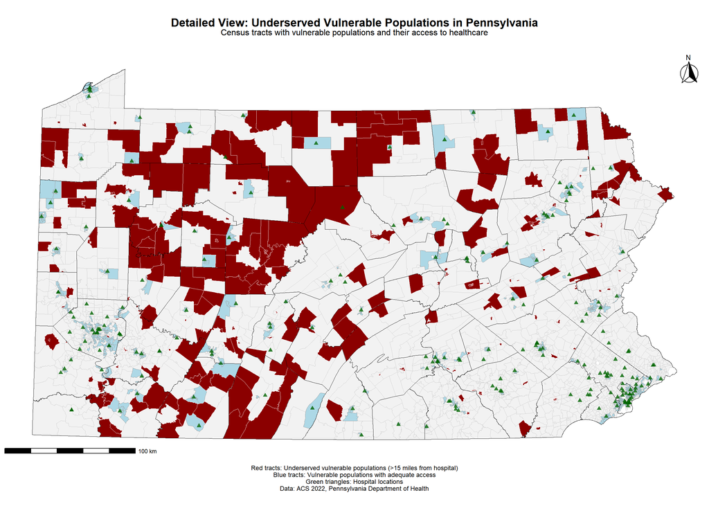

```r
# Create detailed tract-level map
# Create tract categories for visualization
tract_categories <- vulnerable_tracts_final %>%
  mutate(
    tract_category = case_when(
      underserved ~ "Underserved Vulnerable",
      vulnerable ~ "Vulnerable (Served)",
      TRUE ~ "Non-vulnerable"
    ),
    tract_category = factor(tract_category,
                           levels = c("Non-vulnerable", "Vulnerable (Served)", "Underserved Vulnerable"))
  )

# Create the detailed vulnerability map
map2 <- ggplot() +
  # All tracts (non-vulnerable) - light background
  geom_sf(data = tract_categories %>% filter(tract_category == "Non-vulnerable"),
          fill = "grey95", color = "grey80", size = 0.1) +
  # Vulnerable but served tracts
  geom_sf(data = tract_categories %>% filter(tract_category == "Vulnerable (Served)"),
          fill = "lightblue", color = "grey60", size = 0.2) +
  # Underserved vulnerable tracts - highlight these
  geom_sf(data = tract_categories %>% filter(tract_category == "Underserved Vulnerable"),
          fill = "darkred", color = "white", size = 0.3) +
  # County boundaries for context
  geom_sf(data = pa_counties_proj,
          fill = NA, color = "black", size = 0.5) +
  # Hospital locations
  geom_sf(data = hospitals_proj,
          color = "darkgreen", size = 2, shape = 17, alpha = 0.8) +
  # Color scale for legend
  scale_fill_manual(
    name = "Tract Category",
    values = c("Non-vulnerable" = "grey95",
               "Vulnerable (Served)" = "lightblue",
               "Underserved Vulnerable" = "darkred"),
    guide = guide_legend(override.aes = list(size = 0.5))
  ) +
  # Theme and labels
  theme_void() +
  labs(
    title = "Detailed View: Underserved Vulnerable Populations in Pennsylvania",
    subtitle = "Census tracts with vulnerable populations and their access to healthcare",
    caption = "Red tracts: Underserved vulnerable populations (>15 miles from hospital)\nBlue tracts: Vulnerable populations with adequate access\nGreen triangles: Hospital locations\nData: ACS 2022, Pennsylvania Department of Health"
  ) +
  theme(
    plot.title = element_text(size = 16, face = "bold", hjust = 0.5),
    plot.subtitle = element_text(size = 12, hjust = 0.5, margin = margin(b = 20)),
    plot.caption = element_text(size = 9, hjust = 0.5, margin = margin(t = 10)),
    legend.position = "bottom",
    legend.title = element_text(size = 10, face = "bold"),
    legend.text = element_text(size = 9)
  ) +
  # Add north arrow and scale bar
  annotation_north_arrow(location = "tr", which_north = "true",
                        style = north_arrow_fancy_orienteering) +
  annotation_scale(location = "bl", width_hint = 0.3)

# Display the map
print(map2)
```

**Requirements:**

- Show underserved vulnerable tracts in a contrasting color
- Include county boundaries for context
- Show hospital locations
- Use appropriate visual hierarchy (what should stand out?)
- Include informative title and subtitle

### Chart: Distribution Analysis

Create a visualization showing the distribution of distances to hospitals for vulnerable populations.

**Your Task:**

[figure not shown]

```r
# Create distribution visualization
# Create a combined histogram and box plot showing distance distribution
library(patchwork)

# Prepare data for visualization
chart_data <- vulnerable_tracts_final %>%
  filter(vulnerable) %>%  # Only show vulnerable tracts
  mutate(
    category = ifelse(underserved, "Underserved", "Adequate Access"),
    category = factor(category, levels = c("Adequate Access", "Underserved"))
  )

# Create histogram
hist_plot <- ggplot(chart_data, aes(x = distance_to_hospital_miles, fill = category)) +
  geom_histogram(bins = 30, alpha = 0.7, position = "identity") +
  geom_vline(xintercept = 15, linetype = "dashed", color = "red", size = 1) +
  scale_fill_manual(values = c("Adequate Access" = "lightblue", "Underserved" = "darkred")) +
  labs(
    title = "Distribution of Distance to Nearest Hospital",
    subtitle = "For vulnerable census tracts in Pennsylvania",
    x = "Distance to Nearest Hospital (miles)",
    y = "Number of Census Tracts",
    fill = "Access Category"
  ) +
  theme_minimal() +
  theme(
    plot.title = element_text(size = 14, face = "bold"),
    plot.subtitle = element_text(size = 12),
    legend.position = "bottom"
  ) +
  annotate("text", x = 15, y = Inf, label = "15-mile threshold",
           hjust = -0.1, vjust = 1.5, color = "red", size = 3)

# Create box plot by category
box_plot <- ggplot(chart_data, aes(x = category, y = distance_to_hospital_miles, fill = category)) +
  geom_boxplot(alpha = 0.7) +
  geom_hline(yintercept = 15, linetype = "dashed", color = "red", size = 1) +
  scale_fill_manual(values = c("Adequate Access" = "lightblue", "Underserved" = "darkred")) +
  labs(
    title = "Distance Distribution by Access Category",
    x = "Access Category",
    y = "Distance to Nearest Hospital (miles)",
    fill = "Access Category"
  ) +
  theme_minimal() +
  theme(
    plot.title = element_text(size = 14, face = "bold"),
    legend.position = "none"
  ) +
  coord_flip()

# Combine plots
combined_chart <- hist_plot / box_plot +
  plot_annotation(
    title = "Healthcare Access Analysis: Distance to Hospitals for Vulnerable Populations",
    caption = "Data: ACS 2022, Pennsylvania Department of Health. Vulnerable = low-income + high elderly population.",
    theme = theme(plot.title = element_text(size = 16, face = "bold", hjust = 0.5))
  )

# Display the combined chart
print(combined_chart)
```

```r
# Summary statistics for interpretation
cat("Underserved tracts median distance:",
    round(median(chart_data$distance_to_hospital_miles[chart_data$underserved]), 1), "miles\n")
```

```
Underserved tracts median distance: 30.8 miles
```

```r
cat("Adequate access tracts median distance:", round(median(chart_data$distance_to_hospital_miles[!chart_data$underserved]), 1),
    "miles\n")
```

```
Adequate access tracts median distance: 4.4 miles
```

**Suggested chart types:**

- Histogram or density plot of distances
- Box plot comparing distances across regions
- Bar chart of underserved tracts by county
- Scatter plot of distance vs. vulnerable population size

**Requirements:**

- Clear axes labels with units
- Appropriate title
- Professional formatting
- Brief interpretation (1-2 sentences as a caption or in text)

## Part 3: Bring Your Own Data Analysis

Choose your own additional spatial dataset and conduct a supplementary analysis.

### Challenge Options

Choose ONE of the following challenge exercises, or propose your own research question using OpenDataPhilly data (https://opendataphilly.org/datasets/).

**Note these are just loose suggestions to spark ideas - follow or make your own as the data permits and as your ideas evolve. This analysis should include bringing in your own dataset, ensuring the projection/CRS of your layers align and are appropriate for the analysis (not lat/long or geodetic coordinate systems). The analysis portion should include some combination of spatial and attribute operations to answer a relatively straightforward question**

#### Education & Youth Services

**Option A: Educational Desert Analysis** - **Data:** Schools, Libraries, Recreation Centers, Census tracts (child population) - **Question:** “Which neighborhoods lack adequate educational infrastructure for children?” - **Operations:** Buffer schools/libraries (0.5 mile walking distance), identify coverage gaps, overlay with child population density - **Policy relevance:** School district planning, library placement, after-school program siting

**Option B: School Safety Zones** - **Data:** Schools, Crime Incidents, Bike Network - **Question:** “Are school zones safe for walking/biking, or are they crime hotspots?” - **Operations:** Buffer schools (1000ft safety zone), spatial join with crime incidents, assess bike infrastructure coverage - **Policy relevance:** Safe Routes to School programs, crossing guard placement

#### Environmental Justice

**Option C: Green Space Equity** - **Data:** Parks, Street Trees, Census tracts (race/income demographics) - **Question:** “Do low-income and minority neighborhoods have equitable access to green space?” - **Operations:** Buffer parks (10-minute walk = 0.5 mile), calculate tree canopy or park acreage per capita, compare by demographics - **Policy relevance:** Climate resilience, environmental justice, urban forestry investment —

#### Public Safety & Justice

**Option D: Crime & Community Resources** - **Data:** Crime Incidents, Recreation Centers, Libraries, Street Lights - **Question:** “Are high-crime areas underserved by community resources?” - **Operations:** Aggregate crime counts to census tracts or neighborhoods, count community resources per area, spatial correlation analysis - **Policy relevance:** Community investment, violence prevention strategies —

#### Infrastructure & Services

**Option E: Polling Place Accessibility** - **Data:** Polling Places, SEPTA stops, Census tracts (elderly population, disability rates) - **Question:** “Are polling places accessible for elderly and disabled voters?” - **Operations:** Buffer polling places and transit stops, identify vulnerable populations, find areas lacking access - **Policy relevance:** Voting rights, election infrastructure, ADA compliance

#### Health & Wellness

**Option F: Recreation & Population Health** - **Data:** Recreation Centers, Playgrounds, Parks, Census tracts (demographics) - **Question:** “Is lack of recreation access associated with vulnerable populations?” - **Operations:** Calculate recreation facilities per capita by neighborhood, buffer facilities for walking access, overlay with demographic indicators - **Policy relevance:** Public health investment, recreation programming, obesity prevention

#### Emergency Services

**Option G: EMS Response Coverage** - **Data:** Fire Stations, EMS stations, Population density, High-rise buildings - **Question:** “Are population-dense areas adequately covered by emergency services?” - **Operations:** Create service area buffers (5-minute drive = ~2 miles), assess population coverage, identify gaps in high-density areas - **Policy relevance:** Emergency preparedness, station siting decisions

#### Arts & Culture

**Option H: Cultural Asset Distribution** - **Data:** Public Art, Museums, Historic sites/markers, Neighborhoods - **Question:** “Do all neighborhoods have equitable access to cultural amenities?” - **Operations:** Count cultural assets per neighborhood, normalize by population, compare distribution across demographic groups - **Policy relevance:** Cultural equity, tourism, quality of life, neighborhood identity

### Data Sources

**OpenDataPhilly:** https://opendataphilly.org/datasets/ - Most datasets available as GeoJSON, Shapefile, or CSV with coordinates - Always check the Metadata for a data dictionary of the fields.

**Additional Sources:** - **Pennsylvania Open Data:** https://data.pa.gov/ - **Census Bureau (via tidycensus):** Demographics, economic indicators, commute patterns - **TIGER/Line (via tigris):** Geographic boundaries

### Recommended Starting Points

**If you’re feeling confident:** Choose an advanced challenge with multiple data layers. **If you are a beginner, choose something more manageable that helps you understand the basics**

**If you have a different idea:** Propose your own question! Just make sure: - You can access the spatial data - You can perform at least 2 spatial operations

### Your Analysis

**Your Task:**

1. **Find and load additional data**
   - Document your data source
   - Check and standardize the CRS
   - Provide basic summary statistics

```r
# Load your additional dataset
# For this analysis, I'll use Philadelphia Bus Transit Shelters data from OpenDataPhilly
# This will help us understand if vulnerable populations have adequate public transit access to hospitals

# Load Bus Transit Shelters data
bus_shelters <- st_read(here("assignments", "assignment_2", "data", "bus_transit_shelters.geojson"), quiet = TRUE)

# Transform to Pennsylvania State Plane South CRS to match our analysis
bus_shelters <- st_transform(bus_shelters, pa_crs)

# Create summary table of bus shelter data
bus_shelter_summary <- data.frame(
  Metric = c("Number of Bus Shelters", "CRS"),
  Value = c(nrow(bus_shelters), st_crs(bus_shelters)$input)
)

kable(bus_shelter_summary,
      col.names = c("Metric", "Value"),
      caption = "Bus Shelter Dataset Summary",
      align = c("l", "l"))
```

Bus Shelter Dataset Summary

| Metric | Value |
| --- | --- |
| Number of Bus Shelters | 487 |
| CRS | EPSG:2272 |

```r
# Show summary of shelter types
shelter_types <- table(bus_shelters$productgroup)
shelter_types_df <- data.frame(
  Product_Group = names(shelter_types),
  Count = as.numeric(shelter_types)
)

kable(shelter_types_df,
      col.names = c("Product Group", "Count"),
      caption = "Bus Shelter Types Distribution",
      align = c("l", "c"))
```

Bus Shelter Types Distribution

| Product Group | Count |
| --- | --- |
| Digital | 60 |
| Static | 427 |

```r
# Show first few shelter locations
shelter_sample <- bus_shelters %>%
  st_drop_geometry() %>%
  select(site, siteid, productgroup) %>%
  head(6)

kable(shelter_sample,
      col.names = c("Site", "Site ID", "Product Group"),
      caption = "Sample Bus Shelter Locations",
      align = c("l", "l", "l"))
```

Sample Bus Shelter Locations

| Site | Site ID | Product Group |
| --- | --- | --- |
| Chestnut St & 60th St - | pa-002294 | Static |
| Roosevelt Blvd & Broad St NE | pa-002180 | Static |
| Roosevelt Blvd & Broad St - FS SE | pa-002181 | Static |
| 35th & Grays Ferry NE | pa-002338 | Static |
| 60th St & Haverford Av NW | pa-001485 | Static |
| Grays Ferry Av & 35th St - | pa-002284 | Static |

**Questions to answer:**

- What dataset did you choose and why?  
  **Philadelphia Bus Transit Shelters** - public transit affects healthcare access for vulnerable populations without cars.
- What is the data source and date?  
  **OpenDataPhilly** (Philadelphia city open data), **2025**
- How many features does it contain? **487 bus shelters**
- What CRS is it in? Did you need to transform it?  
  Original: WGS 84. Transformed to PA State Plane South (EPSG:2272) for distance calculations.
2. **Pose a research question**

**Research Question:** “Do vulnerable populations in Philadelphia have adequate access to bus transit shelters, and how does this relate to hospital access?”

This analysis examines the spatial relationship between vulnerable tracts (low-income OR high elderly), bus shelters, and hospitals in Philadelphia.

3. **Conduct spatial analysis**

Use at least TWO spatial operations to answer your research question.

**Required operations (choose 2+):**

- Buffers
- Spatial joins
- Spatial filtering with predicates
- Distance calculations
- Intersections or unions
- Point-in-polygon aggregation

**Your Task:**

```r
# Filter for Philadelphia area tracts (bus shelters are concentrated in Philadelphia)
philly_tracts <- vulnerable_tracts_final %>%
  filter(str_detect(NAME, "Philadelphia"))

# Create summary table for Philadelphia analysis
philly_summary <- data.frame(
  Metric = c("Vulnerable Tracts in Philadelphia", "Underserved Tracts in Philadelphia"),
  Count = c(sum(philly_tracts$vulnerable), sum(philly_tracts$underserved))
)

kable(philly_summary,
      col.names = c("Metric", "Count"),
      caption = "Philadelphia Vulnerable Population Summary",
      align = c("l", "c"))
```

Philadelphia Vulnerable Population Summary

| Metric | Count |
| --- | --- |
| Vulnerable Tracts in Philadelphia | 208 |
| Underserved Tracts in Philadelphia | 0 |

```r
# Calculate distance from vulnerable tracts to nearest bus shelter
philly_vulnerable <- philly_tracts %>% filter(vulnerable)
philly_centroids <- st_centroid(philly_vulnerable)
shelter_distances <- st_distance(philly_centroids, bus_shelters)
min_shelter_distances <- apply(shelter_distances, 1, min)
min_shelter_distances_miles <- as.numeric(min_shelter_distances) * 0.000621371

# Add transit access information (0.25 mile = typical walking distance)
philly_vulnerable_with_transit <- philly_vulnerable %>%
  mutate(
    distance_to_shelter_miles = min_shelter_distances_miles,
    has_transit_access = distance_to_shelter_miles <= 0.25,
    transit_accessible = vulnerable & has_transit_access
  )

# Create summary table for transit access analysis
transit_access_summary <- data.frame(
  Metric = c(
    "Average Distance to Bus Shelter",
    "Tracts within 0.25 miles of Shelter",
    "Percentage with Transit Access"
  ),
  Value = c(
    paste(round(mean(min_shelter_distances_miles), 2), "miles"),
    sum(philly_vulnerable_with_transit$has_transit_access),
    paste(round(sum(philly_vulnerable_with_transit$has_transit_access) / nrow(philly_vulnerable_with_transit) * 100, 1), "%")
  )
)

kable(transit_access_summary,
      col.names = c("Metric", "Value"),
      caption = "Transit Access Analysis Summary",
      align = c("l", "l"))
```

Transit Access Analysis Summary

| Metric | Value |
| --- | --- |
| Average Distance to Bus Shelter | 0.87 miles |
| Tracts within 0.25 miles of Shelter | 10 |
| Percentage with Transit Access | 4.8 % |

```r
# Buffer analysis: 0.25 mile buffers around bus shelters
shelter_buffers <- st_buffer(bus_shelters, dist = 402.34)  # 0.25 mile in meters
tracts_in_shelter_buffer <- st_join(philly_vulnerable, shelter_buffers,
                                    join = st_intersects, left = FALSE)

# Create summary table for buffer analysis
buffer_summary <- data.frame(
  Metric = c("Vulnerable Tracts Intersecting Shelter Buffers"),
  Count = c(length(unique(tracts_in_shelter_buffer$GEOID)))
)

kable(buffer_summary,
      col.names = c("Metric", "Count"),
      caption = "Buffer Analysis Summary",
      align = c("l", "c"))
```

Buffer Analysis Summary

| Metric | Count |
| --- | --- |
| Vulnerable Tracts Intersecting Shelter Buffers | 173 |

```r
# Cross-tabulation of transit and hospital access
access_crosstab <- philly_vulnerable_with_transit %>%
  st_drop_geometry() %>%
  mutate(
    transit_status = ifelse(has_transit_access, "Has Transit", "No Transit"),
    hospital_status = ifelse(underserved, "Underserved", "Has Hospital Access")
  ) %>%
  group_by(transit_status, hospital_status) %>%
  summarise(count = n(), .groups = 'drop')

kable(access_crosstab,
      col.names = c("Transit Status", "Hospital Status", "Count"),
      caption = "Cross-tabulation: Transit Access vs Hospital Access",
      align = c("l", "l", "c"))
```

Cross-tabulation: Transit Access vs Hospital Access

| Transit Status | Hospital Status | Count |
| --- | --- | --- |
| Has Transit | Has Hospital Access | 10 |
| No Transit | Has Hospital Access | 198 |

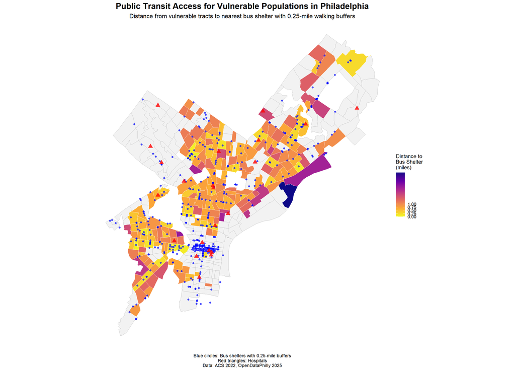

```r
# Create visualization map
transit_map <- ggplot() +
  geom_sf(data = philly_tracts, fill = "gray95", color = "gray70", size = 0.2) +
  geom_sf(data = philly_vulnerable_with_transit,
          aes(fill = distance_to_shelter_miles), color = "white", size = 0.1) +
  geom_sf(data = shelter_buffers, fill = "lightblue", alpha = 0.15, color = NA) +
  geom_sf(data = bus_shelters, color = "blue", size = 1.5, shape = 16, alpha = 0.7) +
  geom_sf(data = hospitals_proj %>%
            filter(st_intersects(geometry, st_union(philly_tracts), sparse = FALSE)),
          color = "red", size = 3, shape = 17, alpha = 0.8) +
  scale_fill_viridis_c(
    name = "Distance to\nBus Shelter\n(miles)",
    option = "plasma",
    direction = -1,
    breaks = c(0, 0.25, 0.5, 0.75, 1.0),
    limits = c(0, max(min_shelter_distances_miles))
  ) +
  theme_void() +
  labs(
    title = "Public Transit Access for Vulnerable Populations in Philadelphia",
    subtitle = "Distance from vulnerable tracts to nearest bus shelter with 0.25-mile walking buffers",
    caption = "Blue circles: Bus shelters with 0.25-mile buffers\nRed triangles: Hospitals\nData: ACS 2022, OpenDataPhilly 2025"
  ) +
  theme(
    plot.title = element_text(size = 16, face = "bold", hjust = 0.5),
    plot.subtitle = element_text(size = 12, hjust = 0.5),
    plot.caption = element_text(size = 9, hjust = 0.5),
    legend.position = "right",
    legend.title = element_text(size = 10),
    legend.text = element_text(size = 9)
  )

print(transit_map)
```

```r
# Create final summary statistics table
final_summary <- data.frame(
  Metric = c(
    "Tracts with Transit Access (<0.25 mi)",
    "Average Distance to Bus Shelter",
    "Maximum Distance to Bus Shelter"
  ),
  Value = c(
    paste(sum(philly_vulnerable_with_transit$has_transit_access),
          "(", round(sum(philly_vulnerable_with_transit$has_transit_access) / nrow(philly_vulnerable_with_transit) * 100, 1), "%)"),
    paste(round(mean(min_shelter_distances_miles), 2), "miles"),
    paste(round(max(min_shelter_distances_miles), 2), "miles")
  )
)

kable(final_summary,
      col.names = c("Metric", "Value"),
      caption = "Final Transit Access Summary Statistics",
      align = c("l", "l"))
```

Final Transit Access Summary Statistics

| Metric | Value |
| --- | --- |
| Tracts with Transit Access (<0.25 mi) | 10 ( 4.8 %) |
| Average Distance to Bus Shelter | 0.87 miles |
| Maximum Distance to Bus Shelter | 3.53 miles |

**Analysis requirements:**

- Clear code comments explaining each step
- Appropriate CRS transformations
- Summary statistics or counts
- At least one map showing your findings
- Brief interpretation of results (3-5 sentences)

**Your interpretation:**

This suggests two issues: (1) Philadelphia’s hospital coverage is good—all vulnerable tracts can reach a hospital within 15 miles; (2) bus shelter distribution may not align well with vulnerable populations’ locations. Many vulnerable residents likely rely on bus stops without shelters.

**I think this analysis only captures shelters, not all bus stops. Many areas have bus service without shelters, which could underestimate actual transit access.**

## Improvements from Assignment 1

Based on feedback from Assignment 1, I have implemented the following key improvements:

- **Protected Census API Key** - Hidden the actual API key from the output
- **Enhanced Table Visualizations** - Replaced raw outputs with professional `kable()` tables
- **Improved Code Documentation** - Added comprehensive comments and better organization
- **Professional Presentation** - Consistent formatting and clear analysis explanations